# Statistical inference with the GSS data

## Setup

### Load packages

```r
library(ggplot2)
library(dplyr)
library(statsr)
```

### Load data

Make sure your data and R Markdown files are in the same directory. When loaded your data file will be called `gss`. Delete this note when before you submit your work.

```r
load("gss.Rdata")
```

## Part 1: Data

The GSS -General Social Survey- is a socilogical survey, monitoring the societal change and contempary american society. it aims to gather data to explain trends and constants in attitudes, behaviors and attributes; to examine the strucure and functionaioning of society in general as well as the role played by relevant subgroups.

The dataset used for this project is an extract of the General Social Survey (GSS) Cumulative File 1972-2012. It consists of 57061 observations with 114 variables. Each variable corresponds to a specific question asked to the respondent. Questions cover a diverse range of issues including national spending priorities, marijuana use, crime and punishment, race relations, quality of life, confidence in institutions, and sexual behavior. The data could project biases as it pertains a long list of questions and the respodents willingness to answer them all.

the study is generalizabile to the US general population, however causal assumptions are not not taken into account due to random sampling and random assignment of treatment was not done. thus any conclusive statement are based on correlation or association based inference.

## Part 2: Research question

There seems a lot of polarization between the different point of views on societal discussions like healthcare and environment. adding on, someones opinion are often cornered into a politcal side e.g. pro-climate is democrat and more conservative views of climate change is occupied by the republicans. However, is the latter actually true? The purpose of the analysis is too cut through narrative and assumptions and look at it in a statistical way.

**Has political affilation impact on someones attitute towards improving and protecting the environment?**

The two categorical variables that will be used are :

- partyid : Politcal party affilation
- natenvir : Attitude towards improving and protecting environment.

## Part 3: Exploratory data analysis

First, look at the data that is of relevance to us.

```r
gss %>%
  group_by(partyid) %>%
  summarise(n=n())
```

```
## # A tibble: 9 x 2
##   partyid                n
##   <fct>              <int>
## 1 Strong Democrat     9117
## 2 Not Str Democrat   12040
## 3 Ind,Near Dem        6743
## 4 Independent         8499
## 5 Ind,Near Rep        4921
## 6 Not Str Republican  9005
## 7 Strong Republican   5548
## 8 Other Party          861
## 9 <NA>                 327
```

```r
gss %>%
  group_by(natenvir) %>%
  summarise(n=n())
```

```
## # A tibble: 4 x 2
##   natenvir        n
##   <fct>       <int>
## 1 Too Little  19259
## 2 About Right  9539
## 3 Too Much     2816
## 4 <NA>        25447
```

Both variables consist of NA’s. Hence, we will clear and put the variables in a seperate dataframe.

```r
df <-gss %>%
  select(partyid, natenvir) %>%
  filter(!is.na(partyid), !is.na(natenvir))
str(df)
```

```
## 'data.frame':    31457 obs. of  2 variables:
##  $ partyid : Factor w/ 8 levels "Strong Democrat",..: 8 2 5 2 5 2 3 2 2 5 ...
##  $ natenvir: Factor w/ 3 levels "Too Little","About Right",..: 3 2 1 1 2 3 1 1 2 1 ...
```

According to the data we can conclude that we are dealing with categorical variables - partyid : Factor w/8 levels -natenvir : Factor w/3 levels

```r
partenv <-table(df$partyid, df$natenvir)
partenv
```

```
##
##                      Too Little About Right Too Much
##   Strong Democrat          3262        1381      320
##   Not Str Democrat         4360        2092      506
##   Ind,Near Dem             2797         921      221
##   Independent              2838        1235      370
##   Ind,Near Rep             1599         900      296
##   Not Str Republican       2756        1710      522
##   Strong Republican        1249        1148      514
##   Other Party               304         107       49
```

```r
prop.table(partenv) %>% round(2) #shows the share across political affilations.
```

```
##
##                      Too Little About Right Too Much
##   Strong Democrat          0.10        0.04     0.01
##   Not Str Democrat         0.14        0.07     0.02
##   Ind,Near Dem             0.09        0.03     0.01
##   Independent              0.09        0.04     0.01
##   Ind,Near Rep             0.05        0.03     0.01
##   Not Str Republican       0.09        0.05     0.02
##   Strong Republican        0.04        0.04     0.02
##   Other Party              0.01        0.00     0.00
```

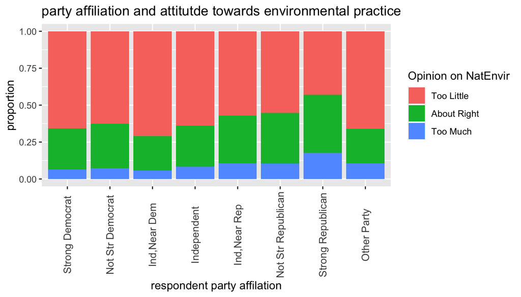

```r
df %>%
  ggplot(aes(x=partyid, fill = natenvir)) +
  geom_bar(position = 'fill') +
  labs(x = 'respondent party affilation', y = 'proportion', title = 'party affiliation and attitutde towards environmental practice ') +
  scale_fill_discrete(name = "Opinion on NatEnvir") +
  theme(axis.text.x = element_text(angle = 90, size = 10, vjust = 0.5))
```

Looking at the stacked the graph, there are slight variations througout the politcal affilations. though, the variations are not as strong, with an exception if you compare the extremes -strong democrats and strong republicans.

## Part 4: Inference

#####Hypothesis H0: Party affilation and attitude towards protection and improvement of environment are indepedent.

Ha: Party affilation and attitude towards protection and improvement of environment are depedent.

#####Method The two variables of interest are categorical variables -partyid and natenvir- and how they relate to each other, both variables consits of multiple levels. For that reason, a chi-square test of indepedence seems the most fitting.

#####Conditions for chi-square test

1. **Indepedence:** sampled observations must be indepedent.
2. Random sample assignment
3. If sampling without replacement, n < 10 % of population
4. Each case only contributes to one cell

The sample size is < 10 % of the US population and each result is counted in one cell.

2. **Sample size**
3. Each particular scenario (i.e. cell) must have atleast 5 expected cases.

There are more than five expected cases for each scenario.

#####Inference test

Because the nature of the study -observational, we can only assume assocication and not causation between the variables.

```r
chisq.test(df$partyid, df$natenvir)$expected
```

```
##                     df$natenvir
## df$partyid           Too Little About Right  Too Much
##   Strong Democrat     3023.6798   1497.8772 441.44305
##   Not Str Democrat    4239.1223   2099.9858 618.89195
##   Ind,Near Dem        2399.8136   1188.8249 350.36151
##   Independent         2706.8727   1340.9366 395.19070
##   Ind,Near Rep        1702.8380    843.5556 248.60635
##   Not Str Republican  3038.9109   1505.4224 443.66672
##   Strong Republican   1773.5103    878.5655 258.92418
##   Other Party          280.2524    138.8321  40.91554
```

```r
chisq.test(df$partyid, df$natenvir)
```

```
##
##  Pearson's Chi-squared test
##
## data:  df$partyid and df$natenvir
## X-squared = 862.6, df = 14, p-value < 2.2e-16
```

#####Interpretation

Pearson’s Chi-squared test leads to a high X-squared with 14 degrees of freedom and a p-value of <2.2e-16. Hence, with an alpha of 0.05, we can reject the null-hypothesis in favor of the alternative hypothesis. concluding that there is evidence that one attitude towards spending in protecting end improving the environment is depedent on political affilation.

```r
inference(data=df, y =natenvir, x = partyid, statistic = 'proportion', type = 'ht', alternative = 'greater', method = 'theoretical')
```

```
## Response variable: categorical (3 levels)
## Explanatory variable: categorical (8 levels)
## Observed:
##                     y
## x                    Too Little About Right Too Much
##   Strong Democrat          3262        1381      320
##   Not Str Democrat         4360        2092      506
##   Ind,Near Dem             2797         921      221
##   Independent              2838        1235      370
##   Ind,Near Rep             1599         900      296
##   Not Str Republican       2756        1710      522
##   Strong Republican        1249        1148      514
##   Other Party               304         107       49
##
## Expected:
##                     y
## x                    Too Little About Right  Too Much
##   Strong Democrat     3023.6798   1497.8772 441.44305
##   Not Str Democrat    4239.1223   2099.9858 618.89195
##   Ind,Near Dem        2399.8136   1188.8249 350.36151
##   Independent         2706.8727   1340.9366 395.19070
##   Ind,Near Rep        1702.8380    843.5556 248.60635
##   Not Str Republican  3038.9109   1505.4224 443.66672
##   Strong Republican   1773.5103    878.5655 258.92418
##   Other Party          280.2524    138.8321  40.91554
##
## H0: partyid and natenvir are independent
## HA: partyid and natenvir are dependent
## chi_sq = 862.6048, df = 14, p_value = 0
```

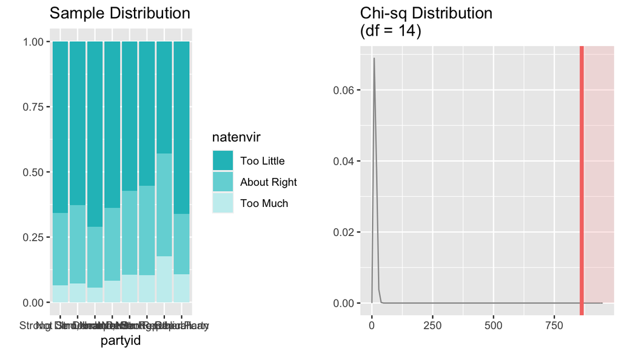